# Core words in semantic representation (supplemental material)

Andrew Wang

01/02/2022

## Full core word lists

|  | AoA | InStrength | WF |
| --- | --- | --- | --- |
| 1 | mom | money | go |
| 2 | potty | food | know |
| 3 | water | water | come |
| 4 | wet | car | like |
| 5 | spoon | music | right |
| 6 | nap | bird | think |
| 7 | dad | sex | good |
| 8 | grandma | love | want |
| 9 | hug | dog | see |
| 10 | shoe | old | say |

[output cut: 290 more lines]

## Full set of hint lists

|  | Target | Target condition | Hint condition | Similarity type | Hint 1 | Hint 2 | Hint 3 | Hint 4 | Hint 5 | Hint 6 |
| --- | --- | --- | --- | --- | --- | --- | --- | --- | --- | --- |
| 1 | arm | AoA | AoA | RW | leg | hand | foot | toe | finger | fingernail |
| 2 | arm | AoA | AoA | word2vec | leg | neck | hand | head | finger | chair |
| 3 | arm | AoA | WF | RW | hand | foot | body | gun | head | shoot |
| 4 | arm | AoA | WF | word2vec | hand | head | body | foot | right | pull |
| 5 | arm | AoA | InStrength | RW | hand | foot | body | gun | army | head |
| 6 | arm | AoA | InStrength | word2vec | hand | head | body | foot | right | eye |
| 7 | bathroom | AoA | AoA | RW | toilet | pee | potty | poop | towel | wash |
| 8 | bathroom | AoA | AoA | word2vec | bedroom | toilet | kitchen | downstairs | upstairs | bed |
| 9 | bathroom | AoA | WF | RW | water | head | drop | door | sit | baby |
| 10 | bathroom | AoA | WF | word2vec | bed | house | door | home | sleep | water |

[output cut: 566 more lines]

## Similarity type

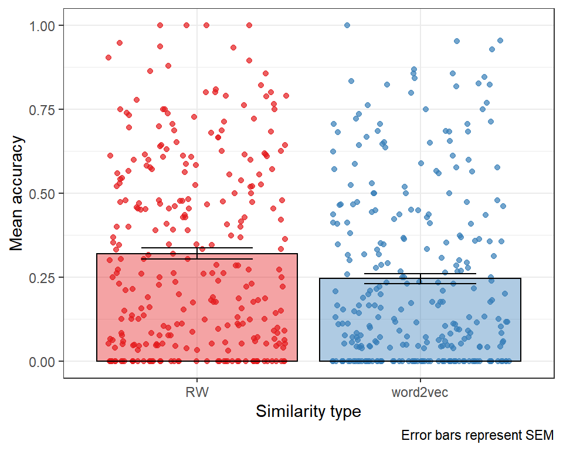

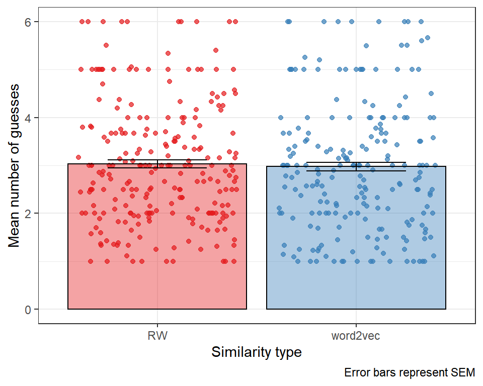

Wilcoxon rank sum tests comparing the two similarity types (RW and word2vec-based) used to select hints for target words revealed that RW trials had significantly higher average accuracy than word2vec-based trials (*p* < .001), but that there was no difference in the number of guesses taken to correctly identify words on average (*p* = .62).

## Main analyses

### RW

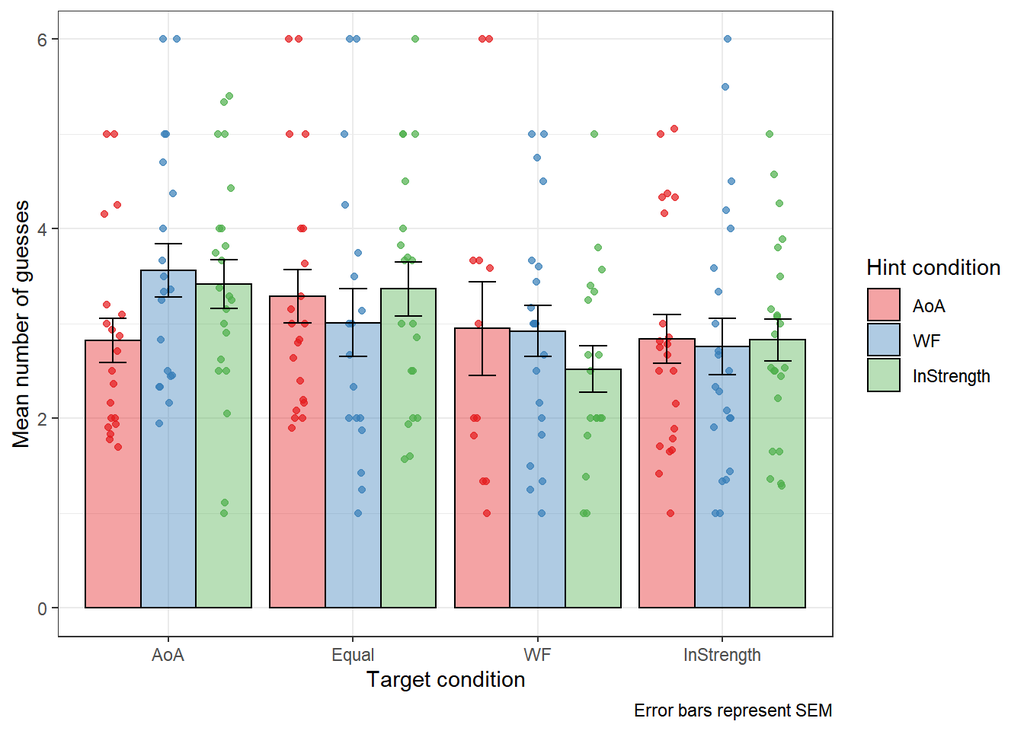

For RW trials, a 4 $\times$ 3 two-way ANOVA comparing mean number of guesses across hint condition and target condition revealed no significant main effects or interaction effects. This indicates that although the target conditions differed in terms of how accurately target words were identified, they did not differ in terms of how many guesses were needed to correctly identify those words.

### word2vec-based

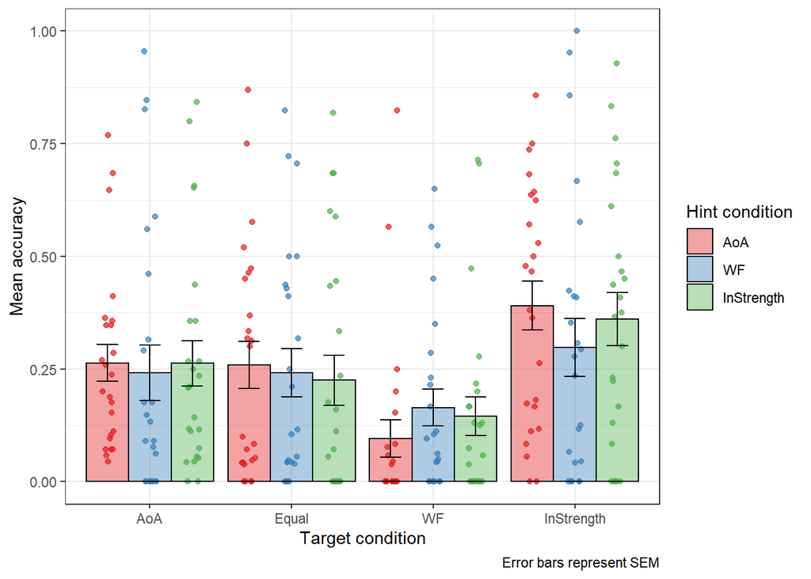

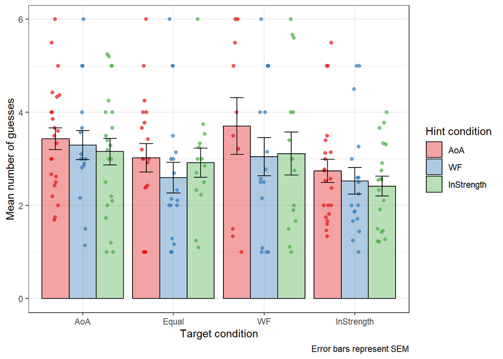

For word2vec-based trials, a 4 $\times$ 3 two-way ANOVA comparing mean accuracy across hint condition and target condition revealed a significant main effect of target condition, *F*(3, 276) = 8.56, *p* < .001, but no significant effects for hint condition or the interaction. Tukey post-hoc pairwise comparisons showed that only the InStrength and WF (*p* < .001) and the AoA and WF target conditions (*p* = .02) differed significantly, with the WF condition being the less accurate in both cases.

A 4 $\times$ 3 two-way ANOVA comparing mean number of guesses across hint condition and target condition revealed a significant main effect of target condition, *F*(3, 202) = 3.78, *p* = .01, with Tukey post-hoc pairwise comparisons showing that InStrength target words took a lower amount of guesses to correctly identify on average compared to the AoA target condition, *p* = .02. No significant effects were found for hint condition or the interaction.

Taken together, these results reflect the same performance hierarchy among target conditions as for accuracy for RW trials: the WF condition had lower accuracy compared to the InStrength and AoA conditions, and although the InStrength and AoA conditions did not differ in terms of accuracy, correct identifications for InStrength target words were quicker than for AoA target words. There were also no differences observed among hint conditions for the word2vec-based trials.

## Part of speech

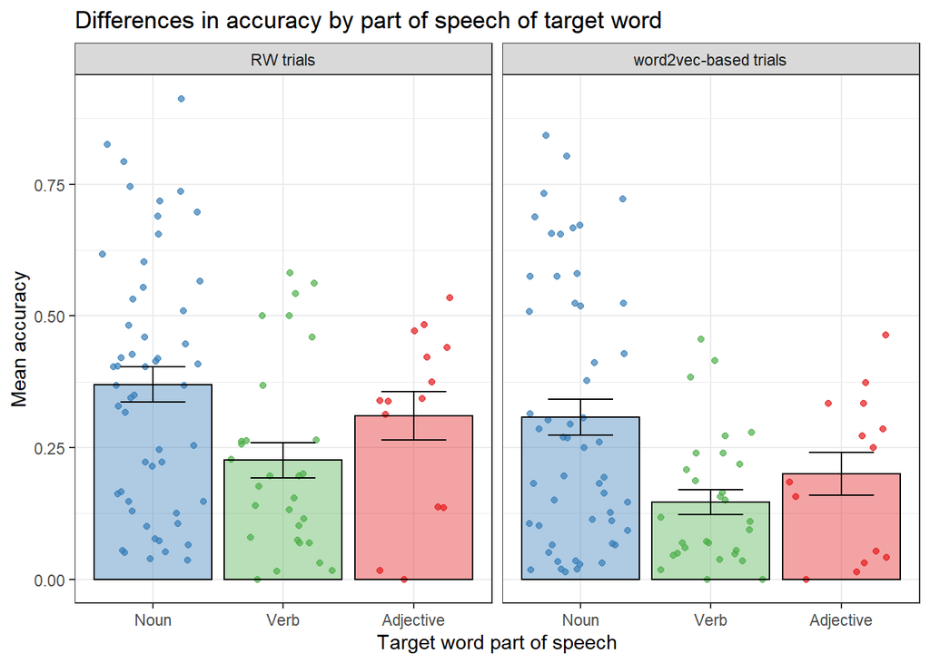

For word2vec-based trials, a Welch ANOVA revealed that the target word part of speech significantly affected accuracy, *F*(2, 38.66) = 7.51, *p* = .002. Post-hoc tests indicated that accuracy was significantly higher for nouns compared to verbs, *p* < .001. (Results for RW trials are reported in the main text.)

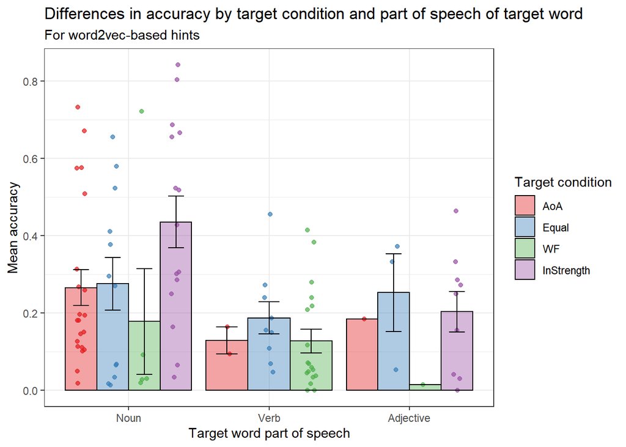

For word2vec-based trials, a Kruskal-Wallis ANOVA for the noun target words only comparing accuracy across target condition was non-significant, *H*(3) = 7.08, p = .07.

## Semantic similarity

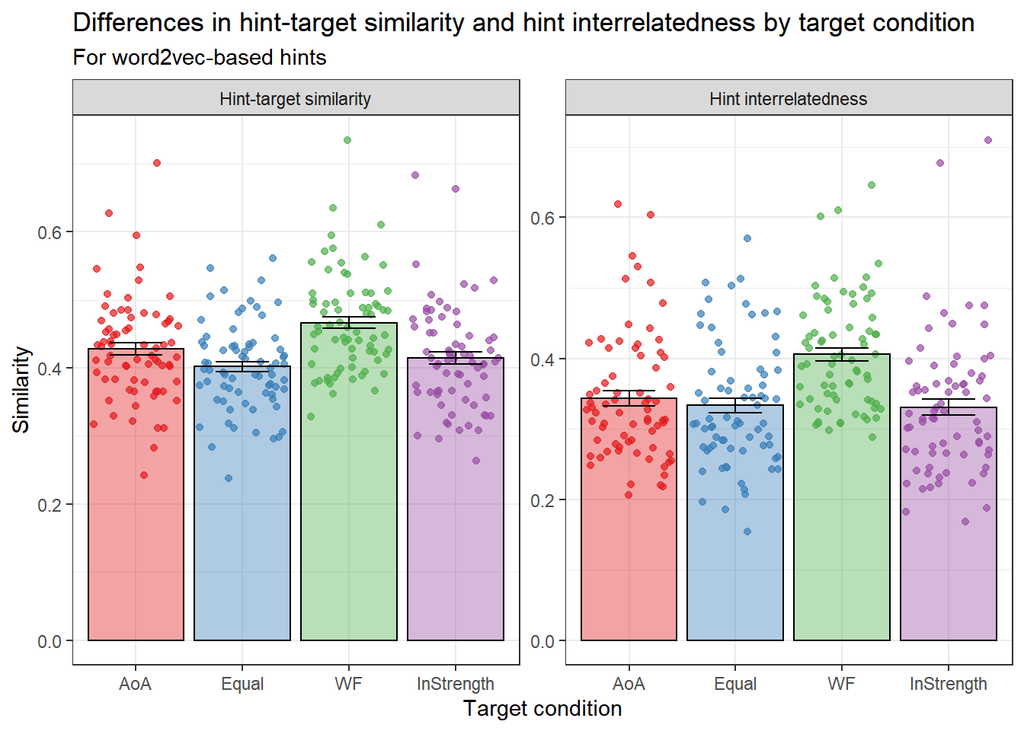

For word2vec-based trials, WF targets had significantly higher similarity to their hints compared to all other conditions (all *p*s < .01), with no significant differences among the others. Hints were most related to each other in the WF condition (all *p*s < .001), with no significant differences among the others.